# Welfare Report

이윤석

2022-06-29

## 1. Data Prepare

- 출처 : https://www.koweps.re.kr:442

### 1-1. 패키지 준비

```r
# install.packages("foreign")
# install.packages("readxl")
```

```r
library(foreign)
library(dplyr)
```

```r
library(ggplot2)
library(readxl)
```

### 1-2. 데이터 불러오기

```r
raw_welfare <- read.spss("C:/RData/Koweps_hpc10_2015_beta1.sav", to.data.frame = T)
# 복사본 만들기
welfare <- raw_welfare
```

### 1-3. 데이터 검토하기

```r
head(welfare)
```

```
##   h10_id h10_ind h10_sn h10_merkey h_new h10_cobf h10_reg5 h10_reg7 h10_din
## 1      1       1      1      10101     0       NA        1        1     864
## 2      2       1      1      20101     0       NA        1        1     600
## 3      3       1      1      30101     0       NA        1        1    1571
## 4      4       1      1      40101     0       NA        1        1    3579
## 5      4       1      1      40101     0       NA        1        1    3579
## 6      6       1      1      60101     0       NA        1        1    3030
##   h10_cin h10_flag   p10_wgl   p10_wsl   p10_wgc   p10_wsc h10_hc nh1001_1
## 1     864        0  776.9947 0.2567795  763.7189 0.2523922      2       NA
## 2     600        0  959.6458 0.3171417  949.2291 0.3136992      2       NA
## 3    1619        0 1059.1559 0.3500276 1047.6591 0.3462281      1       NA
## 4    3687        0 1012.1599 0.3344964  991.5721 0.3276926      1       NA
## 5    3687        0 1075.4212 0.3554029 1057.0466 0.3493305      1       NA
## 6    3486        0 2243.9456 0.7415743 2211.1575 0.7307386      1       NA
##   nh1001_2 h1001_1 h10_pind h10_pid h10_g1 h10_g2 h10_g3 h10_g4 h10_g6 h10_g7
```

[output cut: 895 more lines]

```r
tail(welfare)
```

```
##       h10_id h10_ind h10_sn h10_merkey h_new h10_cobf h10_reg5 h10_reg7 h10_din
## 16659   9800       7      1   98000701     1       NA        4        5    9764
## 16660   9800       7      1   98000701     1       NA        4        5    9764
## 16661   9800       7      1   98000701     1       NA        4        5    9764
## 16662   9800       7      1   98000701     1       NA        4        5    9764
## 16663   9800       7      1   98000701     1       NA        4        5    9764
## 16664   9800       7      1   98000701     1       NA        4        5    9764
##       h10_cin h10_flag   p10_wgl   p10_wsl   p10_wgc   p10_wsc h10_hc nh1001_1
## 16659   11600        0  560.9736 0.1853893  602.8348 0.1992235      1       NA
## 16660   11600        0  536.4383 0.1772810  525.2045 0.1735685      1       NA
## 16661   11600        0  687.1090 0.2270743  679.6506 0.2246095      1       NA
## 16662   11600        0 1262.0316 0.4170735 1248.3326 0.4125463      1       NA
## 16663   11600        0  578.4468 0.1911638  572.1679 0.1890888      1       NA
## 16664   11600        0  554.8621 0.1833696  548.8392 0.1813792      1       NA
##       nh1001_2 h1001_1 h10_pind h10_pid h10_g1 h10_g2 h10_g3 h10_g4 h10_g6
```

[output cut: 944 more lines]

```r
dim(welfare)
```

```
## [1] 16664   957
```

### 1-4. 특성 선택

```r
welfare <- rename(welfare, sex=h10_g3, birth=h10_g4, marriage=h10_g10,
                  religion=h10_g11, income=p1002_8aq1, code_job=h10_eco9,
                  code_region=h10_reg7)
```

```r
welfare <- welfare[, c("sex", "birth", "marriage", "religion", "income", "code_job", "code_region")]
```

```r
str(welfare)
```

```
## 'data.frame':    16664 obs. of  7 variables:
##  $ sex        : num  2 2 1 1 2 1 2 2 1 2 ...
##  $ birth      : num  1936 1945 1948 1942 1923 ...
##  $ marriage   : num  2 2 2 3 2 1 1 0 1 1 ...
##  $ religion   : num  2 2 2 1 1 1 1 1 1 1 ...
##  $ income     : num  NA NA 120 200 NA NA NA NA NA NA ...
##  $ code_job   : num  NA NA 942 762 NA 530 NA NA NA NA ...
##  $ code_region: num  1 1 1 1 1 1 1 1 1 1 ...
```

## 2. EDA

### 2-1. 성별에 따른 월급 차이?

```r
# 성별 변수 검토 1:남자 2:여자
table(welfare$sex)
```

```
##
##    1    2
## 7578 9086
```

```r
# 원급 변수 검토
summary(welfare$income)
```

```
##    Min. 1st Qu.  Median    Mean 3rd Qu.    Max.    NA's
##     0.0   122.0   192.5   241.6   316.6  2400.0   12030
```

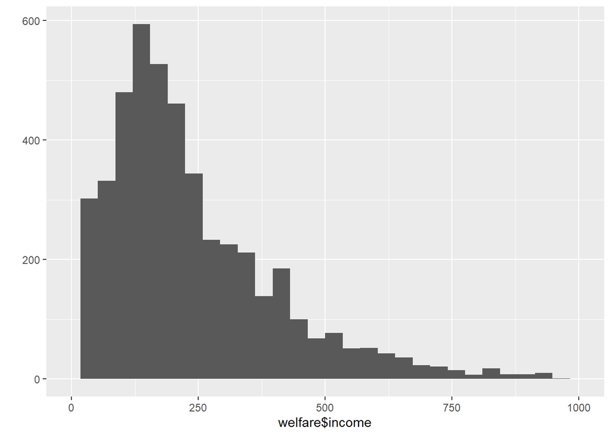

```r
qplot(welfare$income) + xlim(0, 1000)
```

### 2-1-1. 전처리

```r
# 성별 항목에 대한 이름 변경
welfare$sex <- ifelse(welfare$sex == 1, "male", "female")
table(welfare$sex)
```

```
##
## female   male
##   9086   7578
```

```r
# 성별 변수에 대한 전처리: 이상치, 결측치
welfare$sex <- ifelse(welfare$sex == 9, NA, welfare$sex)
table(is.na(welfare$sex))
```

```
##
## FALSE
## 16664
```

```r
# 월급 변수에 대한 전처리: 이상치, 결측치
welfare$income <- ifelse(welfare$income %in% c(0, 9999), NA, welfare$income)
table(is.na(welfare$income))
```

```
##
## FALSE  TRUE
##  4620 12044
```

### 2-1-2. 결론

```r
sex_income <- welfare %>% filter(!is.na(income)) %>% group_by(sex) %>%
  summarise(mean_income=mean(income))

sex_income
```

```
## # A tibble: 2 × 2
##   sex    mean_income
##   <chr>        <dbl>
## 1 female        163.
## 2 male          312.
```

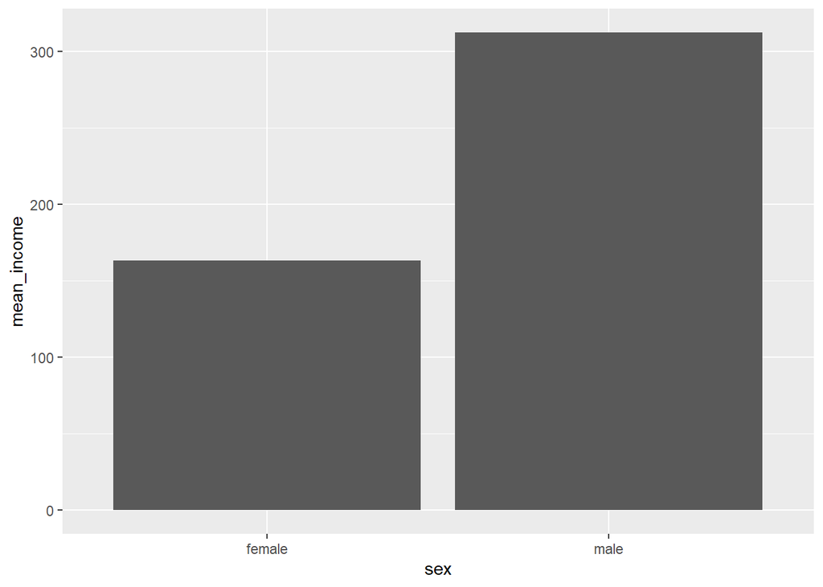

```r
ggplot(sex_income, aes(sex, mean_income)) + geom_col()
```

### 2-2. 몇 살 때 월급을 가장 많이 받을까?

```r
# 변수 검토
class(welfare$birth)
```

```
## [1] "numeric"
```

```r
summary(welfare$birth)
```

```
##    Min. 1st Qu.  Median    Mean 3rd Qu.    Max.
##    1907    1946    1966    1968    1988    2014
```

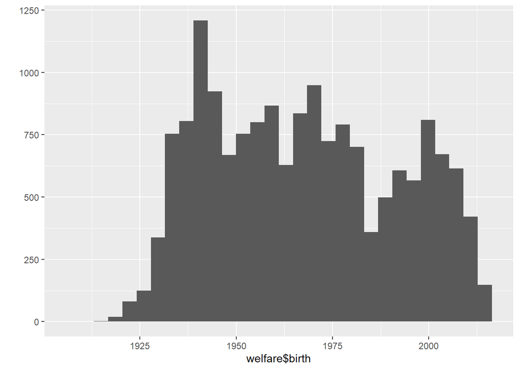

```r
qplot(welfare$birth)
```

### 2-2-1. 전처리

```r
# 이상치 확인
summary(welfare$birth)
```

```
##    Min. 1st Qu.  Median    Mean 3rd Qu.    Max.
##    1907    1946    1966    1968    1988    2014
```

```r
# 결측치 확인
table(is.na(welfare$birth))
```

```
##
## FALSE
## 16664
```

이상치와 결측치가 없다.

```r
# 파생변수 만들기 - 나이
welfare$age <- 2015 - welfare$birth + 1
summary(welfare$age)
```

```
##    Min. 1st Qu.  Median    Mean 3rd Qu.    Max.
##    2.00   28.00   50.00   48.43   70.00  109.00
```

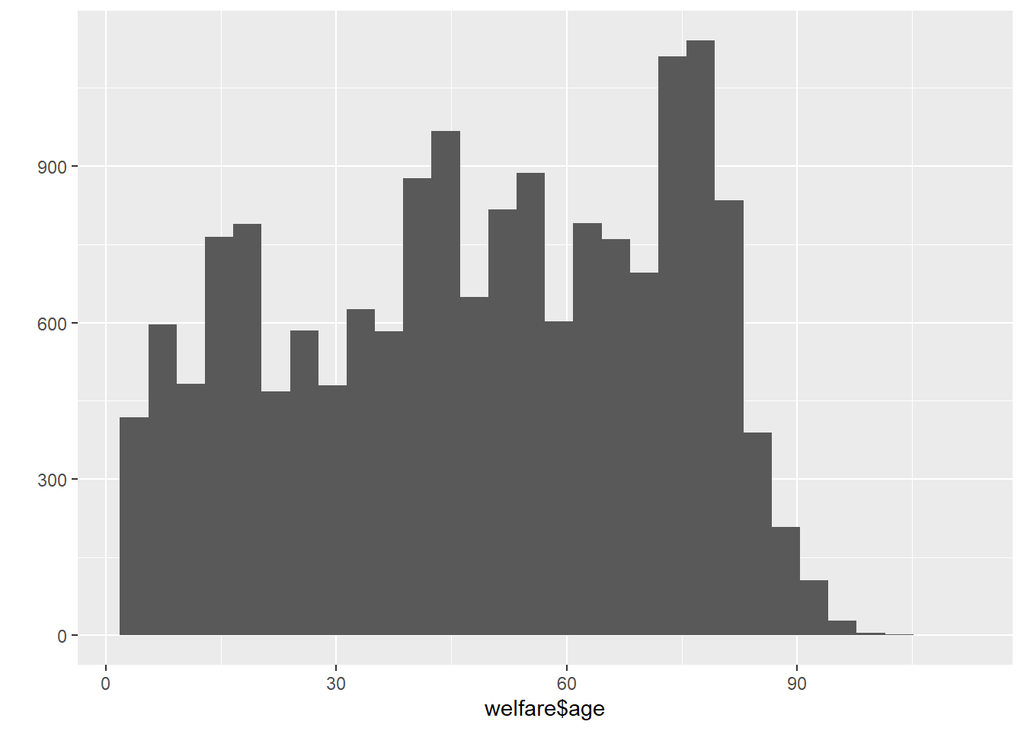

```r
qplot(welfare$age)
```

### 2-2-2.결론

```r
# 1. 나이에 따른 월급 평균표 만들기
age_income <- welfare %>%
  filter(!is.na(income)) %>%
  group_by(age) %>%
  summarise(mean_income=mean(income))

head(age_income)
```

```
## # A tibble: 6 × 2
##     age mean_income
##   <dbl>       <dbl>
## 1    20        121.
## 2    21        106.
## 3    22        130.
## 4    23        142.
## 5    24        134.
## 6    25        145.
```

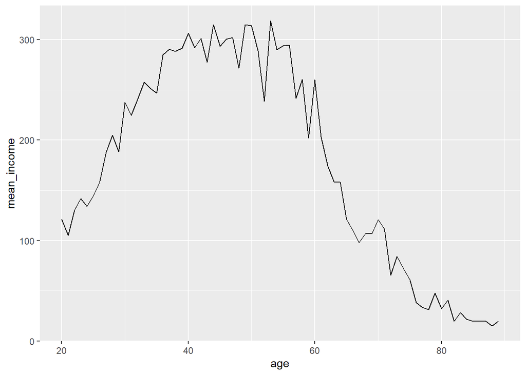

```r
# 2. 그래프 만들기
ggplot(data = age_income, aes(x = age, y = mean_income)) + geom_line()
```

20대 초반 100만원의 월급을 받고 일을 시작하여 40대 까지는 점차 상승하여 300만원의 월급을 50대까지 유지하고, 그 이후 점차 하락하는 추세를 보여준다.

### 2-3. 연령대에 따른 월급차이

```r
# 1. 파생변수 만들기 - 연령대
welfare <- welfare %>% mutate(ageg = ifelse(age < 30, "young",
                              ifelse(age <= 59, "middle", "old")))
table(welfare$ageg)
```

```
##
## middle    old  young
##   6049   6281   4334
```

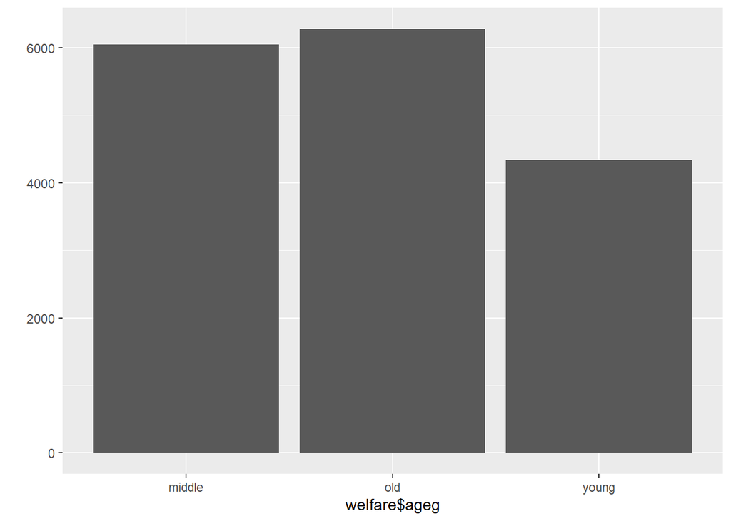

```r
qplot(welfare$ageg)
```

```r
# 2. 연령대에 따른 월급차이 분석하기
```

```r
ageg_income <- welfare %>%
  filter(!is.na(welfare$income)) %>%
  group_by(ageg) %>%
  summarise(mean_income=mean(income))

ageg_income
```

```
## # A tibble: 3 × 2
##   ageg   mean_income
##   <chr>        <dbl>
## 1 middle        282.
## 2 old           125.
## 3 young         164.
```

초년 163만원, 중년 281만원, 노년 125만원이라는 결과를 얻을 수 있다.

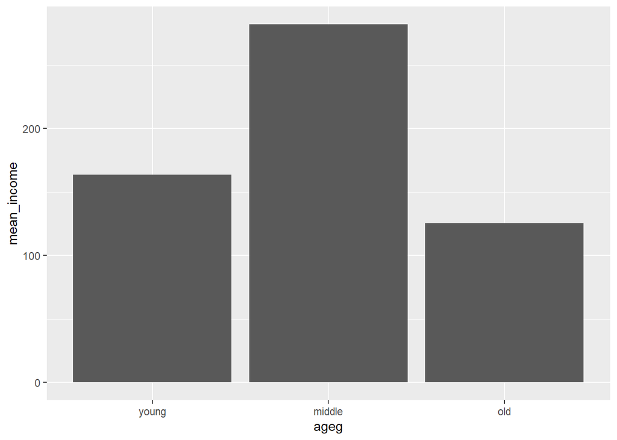

```r
ggplot(data = ageg_income, aes(x = ageg, y = mean_income)) + geom_col() +
  scale_x_discrete(limits = c("young", "middle", "old"))
```

앞서 확인한 바와같이, 중년층의 소득이 가장 높은것을 확인할 수 있다.

### 2-4.연령대 및 성별에 따른 월급 차이

```r
# 1. 연령대 및 성별 월급 평균표 만들기
sex_income <- welfare %>%
  filter(!is.na(income)) %>%
  group_by(ageg, sex) %>%
  summarise(mean_income=mean(income))
sex_income
```

```
## # A tibble: 6 × 3
## # Groups:   ageg [3]
##   ageg   sex    mean_income
##   <chr>  <chr>        <dbl>
## 1 middle female       188.
## 2 middle male         353.
## 3 old    female        81.5
## 4 old    male         174.
## 5 young  female       160.
## 6 young  male         171.
```

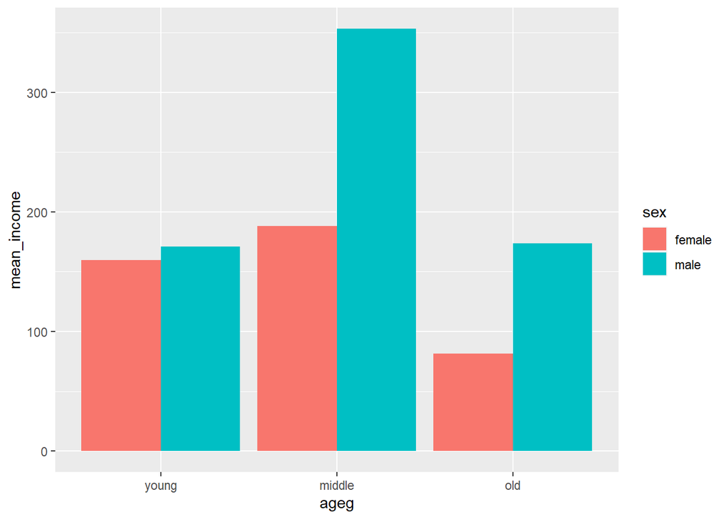

```r
ggplot(data = sex_income, aes(x = ageg, y = mean_income, fill = sex)) + geom_col(position = "dodge")+
  scale_x_discrete(limits = c("young","middle","old"))
```

표에서 보이는 바와 같이 청년층의 경우, 여성과 남성의 소득차이는 별로 없음을 볼 수 있고, 중년층, 장년층에서는 약 두배가량 남성의 소득이 높음을 볼 수 있다. 가장 소득이 높은 층은 중년층 남성이다.

### 2-4.1 나이 및 성별 월급 차이 분석하기

```r
# 성별 연령별 월급 평균표 만들기
sex_age <- welfare %>%
  filter(!is.na(income)) %>%
  group_by(age, sex) %>%
  summarise(mean_income=mean(income))
```

[output not shown]

```r
head(sex_age)
```

```
## # A tibble: 6 × 3
## # Groups:   age [3]
##     age sex    mean_income
##   <dbl> <chr>        <dbl>
## 1    20 female        147.
## 2    20 male           69
## 3    21 female        107.
## 4    21 male          102.
## 5    22 female        140.
## 6    22 male          118.
```

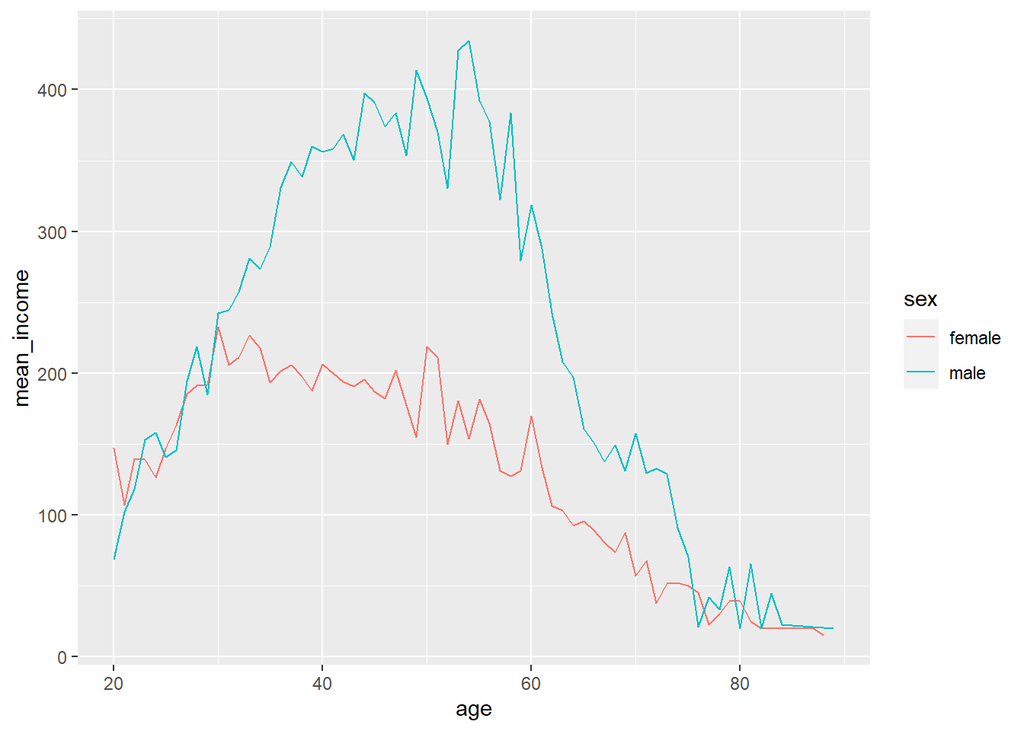

```r
# 그래프 만들기
ggplot(data = sex_age, aes(x = age, y = mean_income, col = sex)) + geom_line()
```

그래프를 보게되면, 여성의 경우 30대 이후 소득이 감소하는 추세를 보이며, 남성의 경우 50대 이후 소득이 감소하는 추세를 보인다. 이는 대부분의 남성이 결혼이후 가정의 소득을 책임지고, 여성은 전업주부로 전향하기 때문으로 보인다.

### 2.5 직업별 월급 차이

```r
# 변수 검토하기
class(welfare$code_job)
```

```
## [1] "numeric"
```

```r
table(welfare$code_job)
```

```
##
##  111  120  131  132  133  134  135  139  141  149  151  152  153  159  211  212
##    2   16   10   11    9    3    7   10   35   20   26   18   15   16    8    4
##  213  221  222  223  224  231  232  233  234  235  236  237  239  241  242  243
##    3   17   31   12    4   41    5    3    6   48   14    2   29   12    4   63
##  244  245  246  247  248  251  252  253  254  259  261  271  272  273  274  281
##    4   33   59   77   38   14  111   24   67  109    4   15   11    4   36   17
##  283  284  285  286  289  311  312  313  314  320  330  391  392  399  411  412
##    8   10   26   16    5  140  260  220   84   75   15    4   13   87   47   12
##  421  422  423  429  431  432  441  442  510  521  522  530  611  612  613  620
##  124   71    5   14   20   33  154  197  192  353    5  106 1320   11   40    2
##  630  710  721  722  730  741  742  743  751  752  753  761  762  771  772  773
##   20   29   30   22   16   27    3   34   34    5   49   69   27   11   61   86
##  774  780  791  792  799  811  812  819  821  822  823  831  832  841  842  843
##    7   17    5   21   45   16    1    6    9    9   23    5   17   32   10    4
##  851  852  853  854  855  861  862  863  864  871  873  874  875  876  881  882
##   19   13    7   33    9    3   14   17   31    2  257   34   37    2    2    3
##  891  892  899  910  921  922  930  941  942  951  952  953  991  992  999 1011
##    8   19   16  102   31   74  289  325   99  125  122   73   45   12  141    2
## 1012
##   17
```

### 2.5.1 전처리

```r
list_job <- read_excel("../data/Koweps_Codebook.xlsx", col_names = T, sheet = 2)
head(list_job)
```

```
## # A tibble: 6 × 2
##   code_job job
##      <dbl> <chr>
## 1      111 의회의원 고위공무원 및 공공단체임원
## 2      112 기업고위임원
## 3      120 행정 및 경영지원 관리자
## 4      131 연구 교육 및 법률 관련 관리자
## 5      132 보험 및 금융 관리자
## 6      133 보건 및 사회복지 관련 관리자
```

```r
dim(list_job)
```

```
## [1] 149   2
```

```r
welfare <- left_join(welfare, list_job, by = "code_job")

welfare %>%
  filter(!is.na(code_job)) %>%
  select(code_job, job) %>%
  head(10)
```

```
##    code_job                                job
## 1       942                   경비원 및 검표원
## 2       762                             전기공
## 3       530 방문 노점 및 통신 판매 관련 종사자
## 4       999        기타 서비스관련 단순 종사원
## 5       312                    경영관련 사무원
## 6       254             문리 기술 및 예능 강사
## 7       510                        영업 종사자
## 8       530 방문 노점 및 통신 판매 관련 종사자
## 9       286   스포츠 및 레크레이션 관련 전문가
## 10      521                   매장 판매 종사자
```

### 2.5.2 결론

```r
# 직업별 월급 차이 분석하기
job_income <- welfare %>%
  filter(!is.na(income)) %>%
  group_by(job) %>%
  summarise(mean_income=mean(income))
head(job_income)
```

```
## # A tibble: 6 × 2
##   job                           mean_income
##   <chr>                               <dbl>
## 1 가사 및 육아 도우미                  80.2
## 2 간호사                              241.
## 3 건설 및 광업 단순 종사원            190.
## 4 건설 및 채굴 기계운전원             358.
## 5 건설 전기 및 생산 관련 관리자       536.
## 6 건설관련 기능 종사자                247.
```

```r
top10 <- job_income %>%
  arrange(desc(mean_income)) %>%
  head(10)
top10
```

```
## # A tibble: 10 × 2
##    job                                  mean_income
##    <chr>                                      <dbl>
##  1 금속 재료 공학 기술자 및 시험원             845.
##  2 의료진료 전문가                             844.
##  3 의회의원 고위공무원 및 공공단체임원         750
##  4 보험 및 금융 관리자                         726.
##  5 제관원 및 판금원                            572.
##  6 행정 및 경영지원 관리자                     564.
##  7 문화 예술 디자인 및 영상 관련 관리자        557.
##  8 연구 교육 및 법률 관련 관리자               550.
##  9 건설 전기 및 생산 관련 관리자               536.
## 10 석유 및 화학물 가공장치 조작원              532.
```

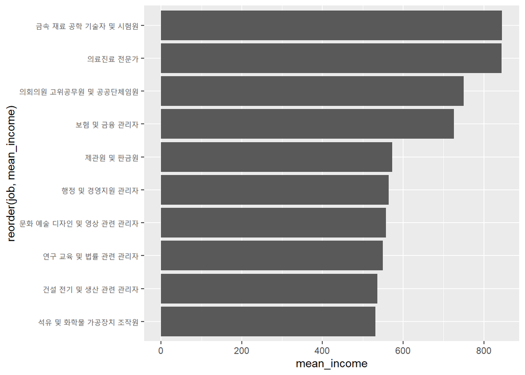

```r
ggplot(data = top10, aes(x = reorder(job, mean_income), y = mean_income)) + geom_col() + coord_flip()
```

가장 높은 소득을 보인 직업은 ’금속 재료공학 기술자 및 시험원’로 845만원 가량 이고, 가장 낮은 소득을 보인 직업은 ’석유 및 화학물 가공장치 조작원’로 531만원 가량 이다.

```r
# 하위 10위 추출
bottom10 <- job_income %>%
  arrange(mean_income) %>%
  head(10)
bottom10
```

```
## # A tibble: 10 × 2
##    job                          mean_income
##    <chr>                              <dbl>
##  1 가사 및 육아 도우미                 80.2
##  2 임업관련 종사자                     83.3
##  3 기타 서비스관련 단순 종사원         88.2
##  4 청소원 및 환경 미화원               88.8
##  5 약사 및 한약사                      89
##  6 작물재배 종사자                     92
##  7 농립어업관련 단순 종사원           102.
##  8 의료 복지 관련 서비스 종사자       104.
##  9 음식관련 단순 종사원               108.
## 10 판매관련 단순 종사원               117.
```

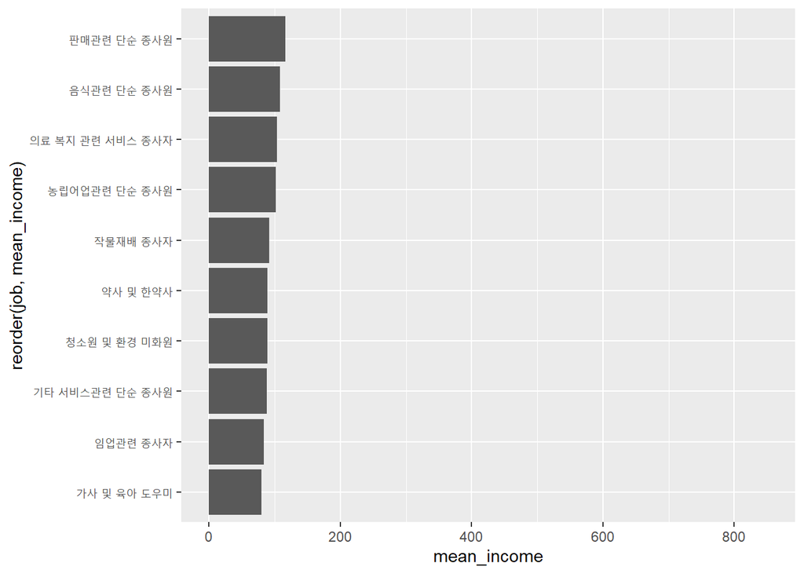

```r
ggplot(data = bottom10, aes(x = reorder(job, mean_income), y = mean_income)) + geom_col() + coord_flip() + ylim(0,850)
```

전체직업군중 가장 소득이 낮게 집계된 직종은 가사 및 육아 도우미 임을 알 수 있고, 다음으로는 임업관련 종사자, 기타 서비스관련 단순 종사원 순임을 알 수 있다.

### 2.6 성별 직업 빈도

```r
### 성별 직업 빈도 분석하기

# 남성 직업 빈도 상위 10개 추출
job_male <- welfare %>%
  filter(!is.na(job) & sex == "male") %>%
  group_by(job) %>%
  summarise(n = n()) %>%
  arrange(desc(n)) %>%
  head(10)

job_male
```

```
## # A tibble: 10 × 2
##    job                          n
##    <chr>                    <int>
##  1 작물재배 종사자            640
##  2 자동차 운전원              251
##  3 경영관련 사무원            213
##  4 영업 종사자                141
##  5 매장 판매 종사자           132
##  6 제조관련 단순 종사원       104
##  7 청소원 및 환경 미화원       97
##  8 건설 및 광업 단순 종사원    95
##  9 경비원 및 검표원            95
## 10 행정 사무원                 92
```

```r
# 여성 직업 빈도 상위 10개 추출
job_female <- welfare %>%
  filter(!is.na(job) & sex == "female") %>%
  group_by(job) %>%
  summarise(n = n()) %>%
  arrange(desc(n)) %>%
  head(10)

job_female
```

```
## # A tibble: 10 × 2
##    job                              n
##    <chr>                        <int>
##  1 작물재배 종사자                680
##  2 청소원 및 환경 미화원          228
##  3 매장 판매 종사자               221
##  4 제조관련 단순 종사원           185
##  5 회계 및 경리 사무원            176
##  6 음식서비스 종사자              149
##  7 주방장 및 조리사               126
##  8 가사 및 육아 도우미            125
##  9 의료 복지 관련 서비스 종사자   121
## 10 음식관련 단순 종사원           104
```

### 2.6.1 시각화

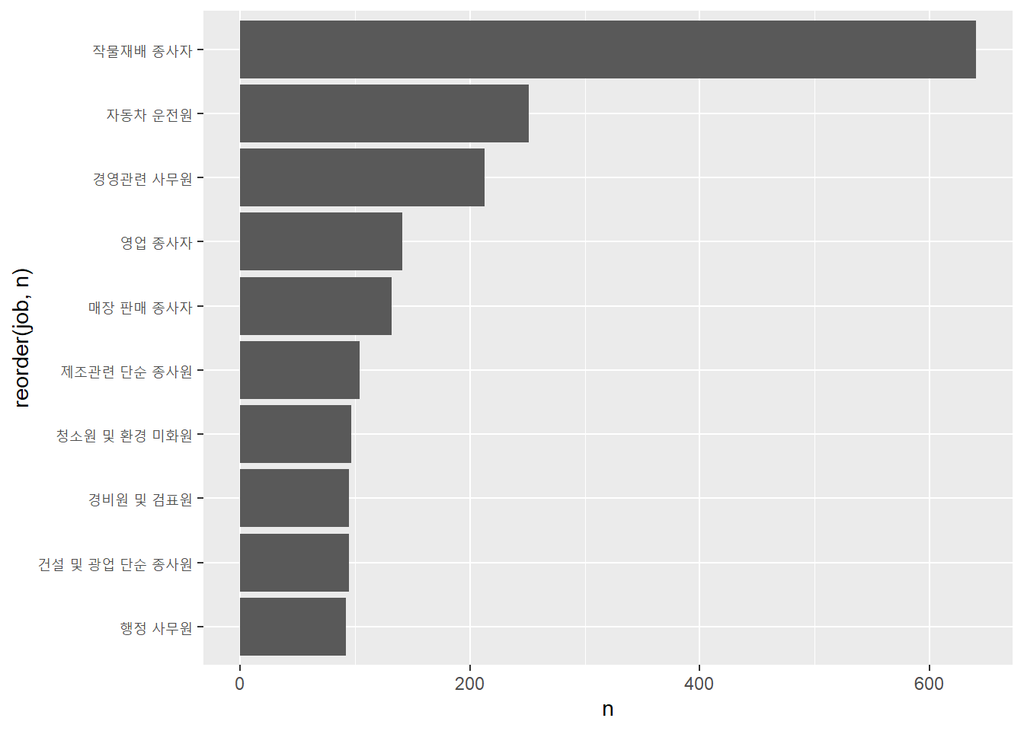

```r
# 남성 직업 빈도 상위 10개
ggplot(data = job_male, aes(x = reorder(job, n), y = n)) + geom_col() + coord_flip()
```

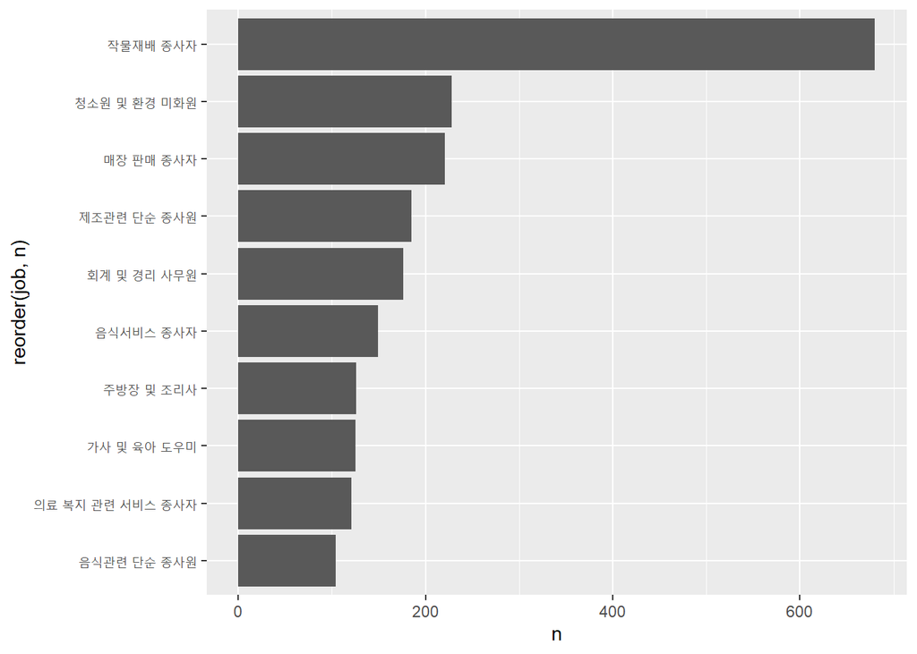

```r
# 여성 직업 빈도 상위 10개
ggplot(data = job_female, aes(x = reorder(job, n), y = n)) + geom_col() + coord_flip()
```

남녀 모두 작물 재배 종사자의 수가 가장 많은 것으로 확인되었으며, 남성의 경우 자동차 운전원, 경영관련 사무원순으로 많았고, 여성의 경우 청소원 및 환경 미화원, 매장판매 종사자순으로 많은 것으로 확인되었다.

### 2.7 종교 유무에 따른 이혼율

```r
# 변수 검토
class(welfare$religion)
```

```
## [1] "numeric"
```

```r
table(welfare$religion)
```

```
##
##    1    2
## 8047 8617
```

### 2.7.1 전처리

```r
# 종교 유무 이름 부여
welfare$religion <- ifelse(welfare$religion == 1, "yes", "no")
table(welfare$religion)
```

```
##
##   no  yes
## 8617 8047
```

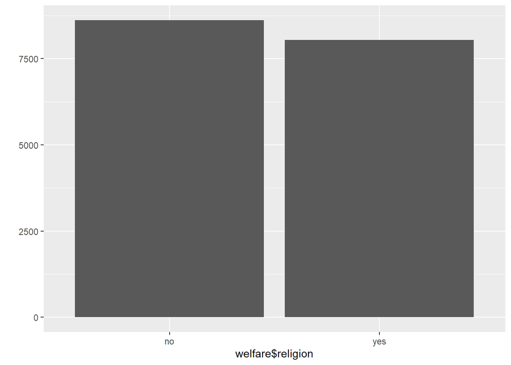

```r
qplot(welfare$religion)
```

```r
# 이혼 여부 변수 만들기

welfare$group_marriage <- ifelse(welfare$marriage == 1, "marraige",
                                 ifelse(welfare$marriage == 3, "divorce", NA))

table(welfare$group_marriage)
```

```
##
##  divorce marraige
##      712     8431
```

```r
table(is.na(welfare$group_marriage))
```

```
##
## FALSE  TRUE
##  9143  7521
```

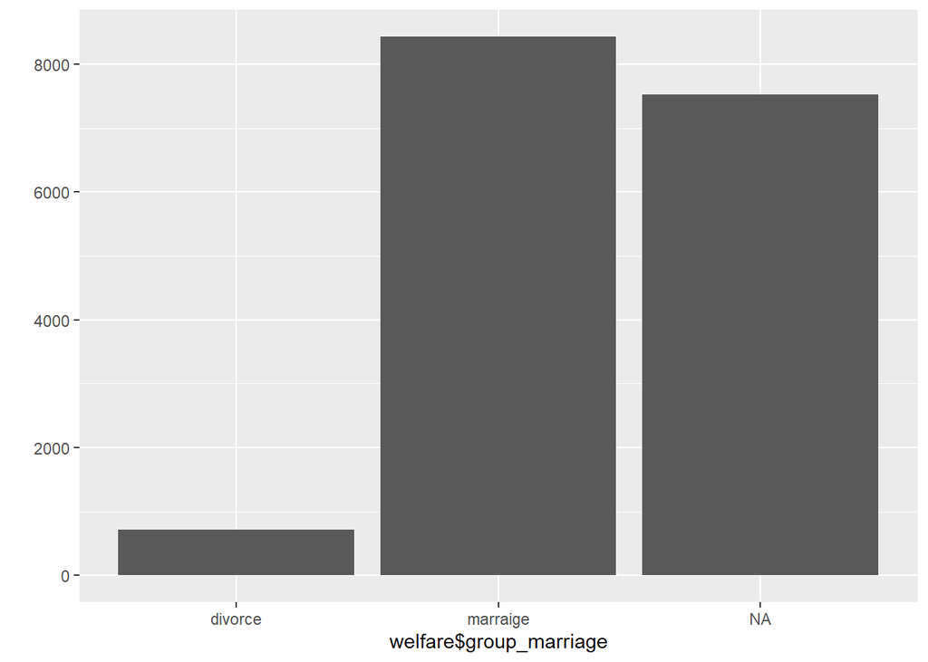

```r
qplot(welfare$group_marriage)
```

### 2.7.3 결론

```r
### 종교 유무에 따른 이혼율 분석하기
religion_marriage <- welfare %>%
  filter(!is.na(group_marriage)) %>%
  group_by(religion, group_marriage) %>%
  summarise(n = n()) %>%
  mutate(tot_group = sum(n)) %>%
  mutate(pct = round(n/tot_group*100, 1))
religion_marriage
```

```
## # A tibble: 4 × 5
## # Groups:   religion [2]
##   religion group_marriage     n tot_group   pct
##   <chr>    <chr>          <int>     <int> <dbl>
## 1 no       divorce          384      4602   8.3
## 2 no       marraige        4218      4602  91.7
## 3 yes      divorce          328      4541   7.2
## 4 yes      marraige        4213      4541  92.8
```

```r
# 이혼 추출
divorce <- religion_marriage %>%
  filter(group_marriage == "divorce") %>%
  select(religion, pct)

divorce
```

```
## # A tibble: 2 × 2
## # Groups:   religion [2]
##   religion   pct
##   <chr>    <dbl>
## 1 no         8.3
## 2 yes        7.2
```

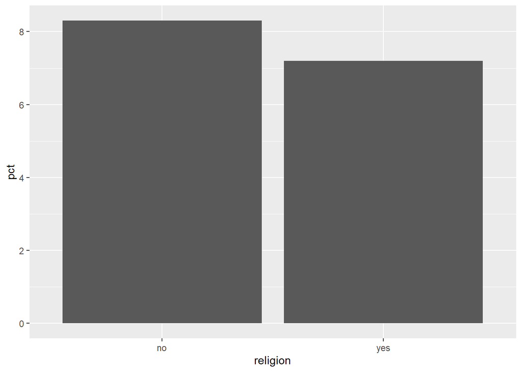

```r
ggplot(data = divorce, aes(x = religion, y = pct)) + geom_col()
```

```r
### 연령대 및 종교 유무에 따른 이혼율 분석하기

# 연령대 별 이혼율
ageg_marriage <- welfare %>%
  filter(!is.na(group_marriage)) %>%
  group_by(ageg, group_marriage) %>%
  summarise(n = n()) %>%
  mutate(tot_group = sum(n)) %>%
  mutate(pct = round(n/sum(n)*100, 1))
ageg_marriage
```

```
## # A tibble: 6 × 5
## # Groups:   ageg [3]
##   ageg   group_marriage     n tot_group   pct
##   <chr>  <chr>          <int>     <int> <dbl>
## 1 middle divorce          437      4918   8.9
## 2 middle marraige        4481      4918  91.1
## 3 old    divorce          273      4165   6.6
## 4 old    marraige        3892      4165  93.4
## 5 young  divorce            2        60   3.3
## 6 young  marraige          58        60  96.7
```

```r
# 초년 제외, 이혼 추출
ageg_divorce <- ageg_marriage %>%
  filter(ageg != "young" & group_marriage == "divorce") %>%
  select(ageg, pct)

ageg_divorce
```

```
## # A tibble: 2 × 2
## # Groups:   ageg [2]
##   ageg     pct
##   <chr>  <dbl>
## 1 middle   8.9
## 2 old      6.6
```

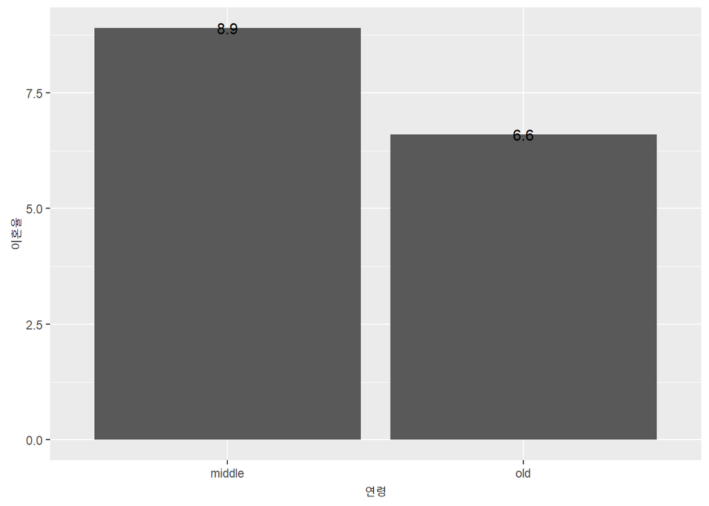

```r
ggplot(ageg_divorce, aes(ageg, pct)) + geom_col() + geom_text(aes(label = pct)) + xlab("연령") + ylab("이혼율")
```

초년의 경우 사례가 부족하기 때문에 제외시켰고, 중년층이 이혼율이 장년층보다 높음을 확인할 수 있따.

```r
# 연령대, 종교 유무, 결혼 상태별 비율표 만들기
ageg_religion_marriage <- welfare %>%
  filter(!is.na(group_marriage) & ageg != "young") %>%
  group_by(ageg, religion, group_marriage) %>%
  summarise(n = n()) %>%
  mutate(tot_group = sum(n)) %>%
  mutate(pct = round(n/sum(n)*100, 1))
ageg_religion_marriage
```

```
## # A tibble: 8 × 6
## # Groups:   ageg, religion [4]
##   ageg   religion group_marriage     n tot_group   pct
##   <chr>  <chr>    <chr>          <int>     <int> <dbl>
## 1 middle no       divorce          260      2681   9.7
## 2 middle no       marraige        2421      2681  90.3
## 3 middle yes      divorce          177      2237   7.9
## 4 middle yes      marraige        2060      2237  92.1
## 5 old    no       divorce          123      1884   6.5
## 6 old    no       marraige        1761      1884  93.5
## 7 old    yes      divorce          150      2281   6.6
## 8 old    yes      marraige        2131      2281  93.4
```

```r
# 연령대 및 종교 유무별 이혼율 표 만들기
df_divorce <- ageg_religion_marriage %>%
  filter(group_marriage == "divorce") %>%
  select(ageg, religion, pct)

df_divorce
```

```
## # A tibble: 4 × 3
## # Groups:   ageg, religion [4]
##   ageg   religion   pct
##   <chr>  <chr>    <dbl>
## 1 middle no         9.7
## 2 middle yes        7.9
## 3 old    no         6.5
## 4 old    yes        6.6
```

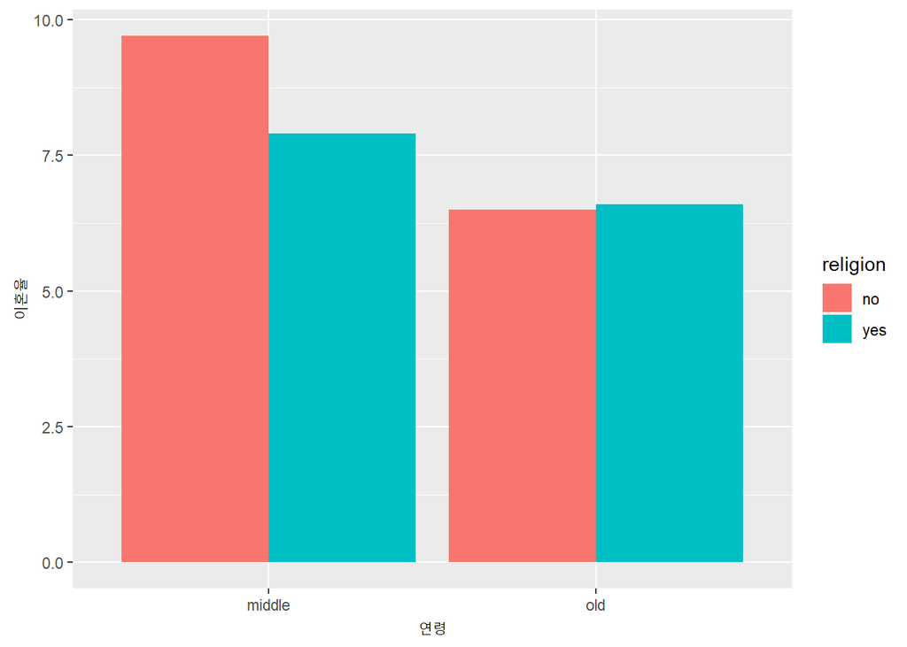

```r
ggplot(df_divorce, aes(ageg, pct, fill=religion)) + geom_col(position="dodge") + xlab("연령") + ylab("이혼율")
```

종교 유무에 대한 기준을 추가해 봤을때, 노년층에서는 유의미한 차이가 없었고, 중년층의 경우 종교가 있을 경우의 이혼율이 조금 더 낮음을 수 있었다.

### 2.8 지역별 연령대 비율

```r
### 지역 변수 검토 및 전처리하기
# 변수 확인
class(welfare$code_region)
```

```
## [1] "numeric"
```

```r
table(welfare$code_region)
```

```
##
##    1    2    3    4    5    6    7
## 2486 3711 2785 2036 1467 1257 2922
```

### 2.8.1 전처리

```r
# 지역 코드 목록 만들기
list_region <- data.frame(code_region = c(1:7),
                          region = c("서울", "수도권(인천/경기)",
                                     "부산/경남/울산", "대구/경북",
                                     "대전/충남", "강원/충북",
                                     "광주/전남/전북/제주도"))

list_region
```

```
##   code_region                region
## 1           1                  서울
## 2           2     수도권(인천/경기)
## 3           3        부산/경남/울산
## 4           4             대구/경북
## 5           5             대전/충남
## 6           6             강원/충북
## 7           7 광주/전남/전북/제주도
```

```r
# 지역명 변수 추가
welfare <- left_join(welfare, list_region, by="code_region")

welfare %>%
  select(code_region, region) %>%
  head
```

```
##   code_region region
## 1           1   서울
## 2           1   서울
## 3           1   서울
## 4           1   서울
## 5           1   서울
## 6           1   서울
```

```r
### 지역별 연령대 비율 분석하기
# 지역별 연령대 비율표
region_ageg <- welfare %>%
  group_by(region, ageg) %>%
  summarise(n=n()) %>%
  mutate(pct = round(n/sum(n)*100, 2))
head(region_ageg)
```

```
## # A tibble: 6 × 4
## # Groups:   region [2]
##   region                ageg       n   pct
##   <chr>                 <chr>  <int> <dbl>
## 1 강원/충북             middle   417  33.2
## 2 강원/충북             old      555  44.2
## 3 강원/충북             young    285  22.7
## 4 광주/전남/전북/제주도 middle   947  32.4
## 5 광주/전남/전북/제주도 old     1233  42.2
## 6 광주/전남/전북/제주도 young    742  25.4
```

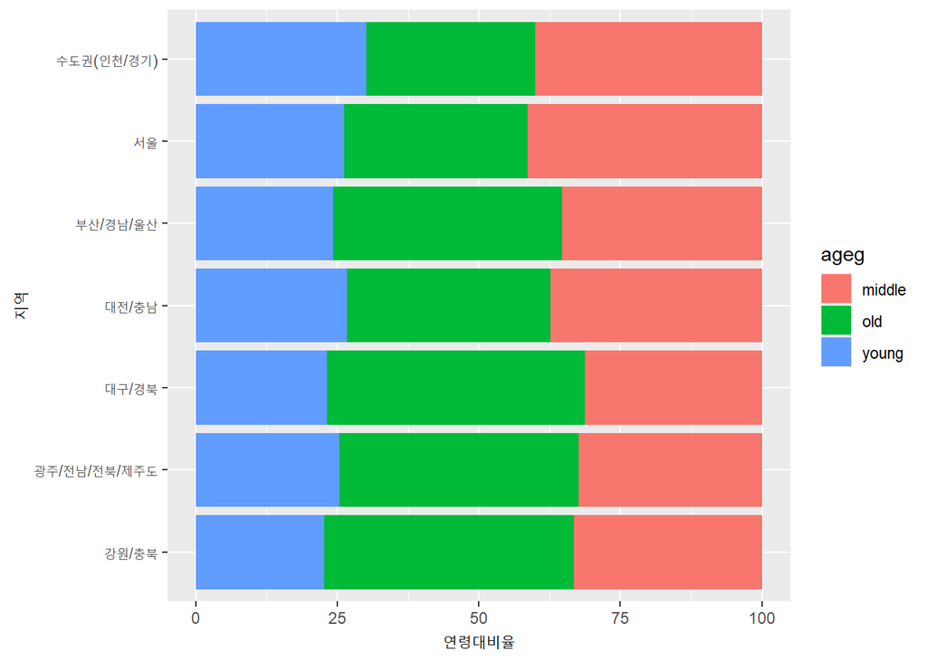

```r
# 그래프
ggplot(region_ageg, aes(region, pct, fill=ageg)) + geom_col() + coord_flip() + xlab("지역") + ylab("연령대비율")
```

```r
# 노년층 비율 내림차순 정렬
list_order_old <- region_ageg %>%
  filter(ageg == "old") %>%
  arrange(pct)

list_order_old
```

```
## # A tibble: 7 × 4
## # Groups:   region [7]
##   region                ageg      n   pct
##   <chr>                 <chr> <int> <dbl>
## 1 수도권(인천/경기)     old    1109  29.9
## 2 서울                  old     805  32.4
## 3 대전/충남             old     527  35.9
## 4 부산/경남/울산        old    1124  40.4
## 5 광주/전남/전북/제주도 old    1233  42.2
## 6 강원/충북             old     555  44.2
## 7 대구/경북             old     928  45.6
```

```r
# 지역별 순서 변수 만들기
order <- list_order_old$region
order
```

```
## [1] "수도권(인천/경기)"     "서울"                  "대전/충남"
## [4] "부산/경남/울산"        "광주/전남/전북/제주도" "강원/충북"
## [7] "대구/경북"
```

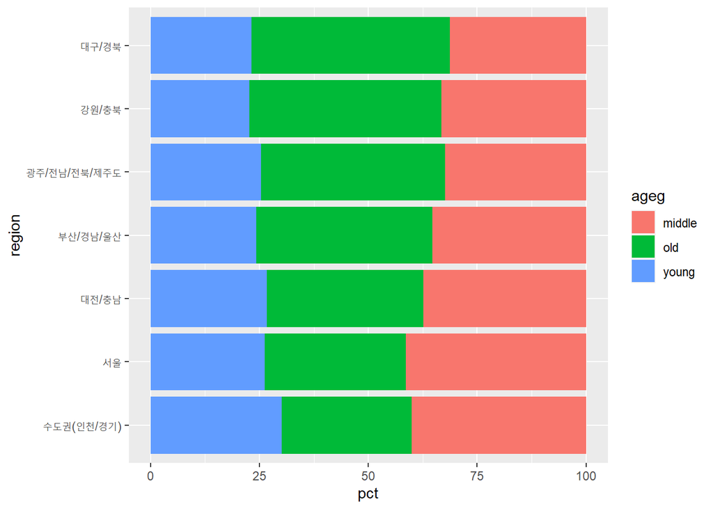

```r
ggplot(region_ageg, aes(region, pct, fill=ageg)) +
  geom_col() +
  coord_flip() +
  scale_x_discrete(limits=order)
```

```r
# 연령대 순으로 다시 정렬
region_ageg$ageg <- factor(region_ageg$ageg, level=c("old", "middle", "young"))
levels(region_ageg$ageg)
```

```
## [1] "old"    "middle" "young"
```

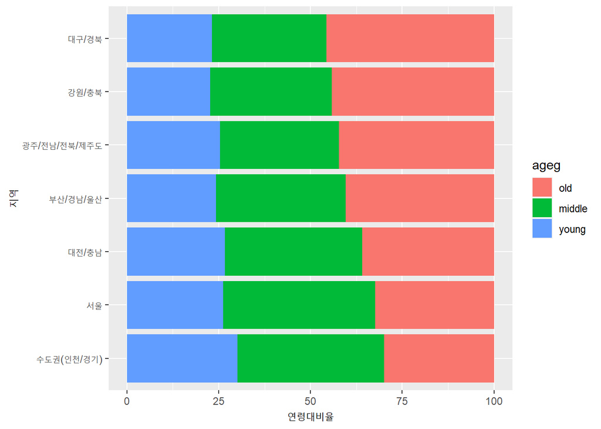

```r
ggplot(region_ageg, aes(region, pct, fill=ageg)) +
  geom_col() +
  coord_flip() +
  scale_x_discrete(limits=order) + xlab("지역") + ylab("연령대비율")
```

장년층의 비율이 가장 높은 지역은 대구/경북 지역이였고, 가장 적은곳은 수도권 지역이였다.